# Biometrie onderzoek

1 mei 2025

```r
# DON'T TOUCH THIS
knitr::opts_chunk$set(echo = TRUE)
library(ggplot2)
```

### Inleiding

Biometrie betekent het vaststellen van meetbare eigenschappen van levende wezens. Dit kan bijvoorbeeld betekenen lichaamsgewicht, lengte van ledematen, levensduur, sexe. Biometrische kenmerken worden ook gebruikt in je paspoort.

4 bio-informatica studenten zijn bezig geweest met het vaststellen van de handlengte/breedte-ratio, in het bijzonder in afhankelijkheid van sekse.

### Onderzoeksvragen

1. Is er een significant sekseverschil bij de mens in de lengte van de hand?
2. Is er een significant sekseverschil bij de mens in de breedte van de hand?
3. Is er een significant sekseverschil bij de mens in de lengte/breedte-ratio van de hand? :::

## hypotheses

1. Er is een significant sekseverschil bij de mens in de lengte van de hand.
2. Er is een significant sekseverschil bij de mens in de breedte van de hand.
3. Er is een significant sekseverschil bij de mens in de lengte/breedte-ratio van de hand. :::

### Nulhypotheses

1. Er is geen significant sekseverschil bij de mens in de lengte van de hand.
2. Er is geen significant sekseverschil bij de mens in de breedte van de hand.
3. Er is geen significant sekseverschil bij de mens in de lengte/breedte-ratio van de hand. :::

### Ontwerp van het experiment

Van 40 willekeurig geselecteerde proefpersonen in en rond het schoolgebouw is de handlengte en -breedte gemeten.

### Protocol

##### Benodigdheden

1. Liniaal.
2. Csv-bestand in de app Excel om resultaten vast te leggen.

##### Data verzamelen

Zoek, samen met een ander groepje van je klas, in of rond het schoolgebouw medestudenten. Vraag beleefd of ze willen participeren in een klein wetenschappelijk onderzoekje voor school waarbij de maten van de hand opgenomen zullen worden.  
Is het antwoord nee, dan groet je vriendelijk en zoek je verder.  
Is het antwoord ja, dan vraag je of de proefpersoon de hand horizontaal en gestrekt wil houden met de palm naar beneden. Vervolgens meet je zowel de lengte als de breedte van de hand op, in centimeters. Deze leg je vast in de spreadsheet, . Kijk of de persoon biologisch gezien een man of een vrouw is. Het “parallel groepje” (dat niet jouw bevindingen mag horen) doet dezelfde metingen in dezelfde volgorde en slaat de gegevens die het gemeten heeft op.  
Bedank de proefpersoon voor deelname.  
Ga door totdat van ten minste 40 proefpersonen de gegevens zijn verzameld.

### Analyse

#### Beschrijvende statistiek

```r
data_file <- "zelf_verzamelde_data_handen.csv"

#data format: laborant_ID,subject_ID,handlengte,handbreedte,sexe
biometric_data <- read.table(file = data_file,
                        header = TRUE,
                        sep = ",")
handlengte <- biometric_data[3]
handbreedte <- biometric_data[2]
lengte_breedte_ratio <- handlengte / handbreedte
# Gebruikte bronnen voor onderstaande code in deze chunk:
# https://stackoverflow.com/questions/13079387/how-to-add-data-by-columns-in-csv-f# ile-using-r#:~:text=You%20can't%20append%20columns,file%20is%20stored%20on%2Ddis# k.
# https://how.dev/answers/what-are-the-rownames-and-colnames-functions-in-r
df_ratio <- data.frame(lengte_breedte_ratio)

tmp <- read.csv("zelf_verzamelde_data_handen.csv")
tmp <- cbind(tmp, df_ratio)
colnames(tmp) <- c("nummer", "handbreedte", "handlengte", "geslacht", "lengte_breedte_ratio")
write.csv(tmp, "zelf_verzamelde_data_handen_v2.csv")
biometric_data <- read.table(file = "zelf_verzamelde_data_handen_v2.csv",
                        header = TRUE,
                        sep = ",")
#split over gender into list of dataframes
geslacht_split_data <- split(x = biometric_data,
      f = biometric_data$geslacht)

#apply a function to report means of both measurements
sapply(X = geslacht_split_data,
       FUN = function(x){
           c(gem_handlengte = mean(x$handlengte),
             gem_handbreedte = mean(x$handbreedte),
             gem_lengte_breedte_ratio = mean(x$lengte_breedte_ratio),
             stdev_handlengte = sd(x$handlengte),
             stdev_handbreedte = sd(x$handbreedte),
             stdev_lengte_breedte_ratio = sd(x$lengte_breedte_ratio))
       })
```

```
##                                   man       vrouw
## gem_handlengte             18.5800000 16.73000000
## gem_handbreedte             9.9700000  9.08000000
## gem_lengte_breedte_ratio    1.8704699  1.84359728
## stdev_handlengte            0.8833322  0.81247222
## stdev_handbreedte           0.6438837  0.44671642
## stdev_lengte_breedte_ratio  0.1417346  0.06498119
```

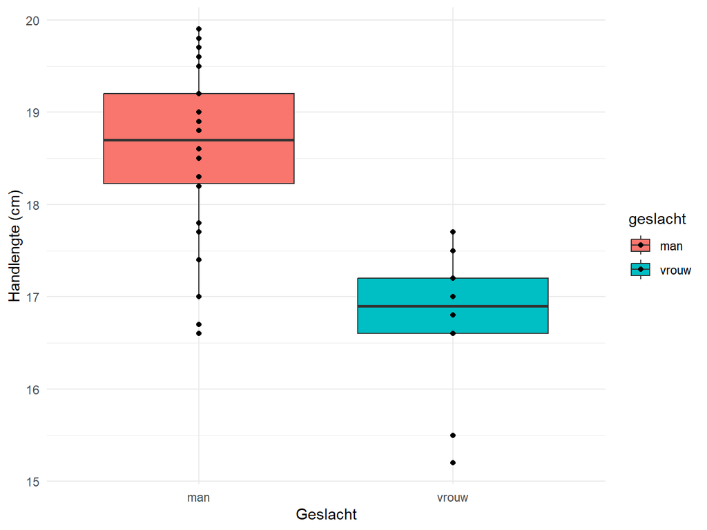

```r
ggplot(data = biometric_data,
       mapping = aes(x = geslacht, y = handlengte, fill = geslacht)) +
    geom_boxplot() +
    geom_point() +
    labs(x = "Geslacht", y = "Handlengte (cm)") +
    theme_minimal()
```

Voor de verschillen aan de hand van twee boxplots is steeds de volgende bron gebruikt: https://content.math4all.nl/sec/content/vc-e6/vc-e63/vc-e63-explanation-1.html De boxen overlappen elkaar niet, dus is er een groot verschil in de handlengte tussen mannen en vrouwen.

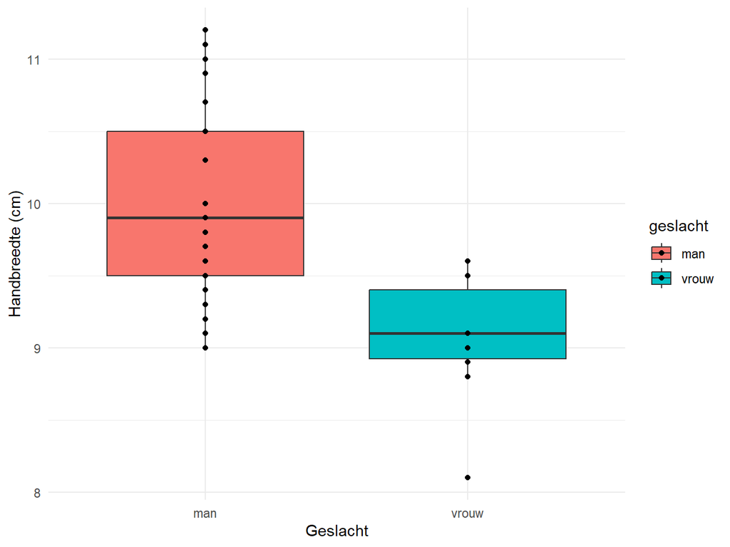

```r
ggplot(data = biometric_data,
       mapping = aes(x = geslacht, y = handbreedte, fill = geslacht)) +
    geom_boxplot() +
    geom_point() +
    labs(x = "Geslacht", y = "Handbreedte (cm)") +
    theme_minimal()
```

De boxen overlappen elkaar niet, dus is er een groot verschil in de handbreedte tussen mannen en vrouwen.

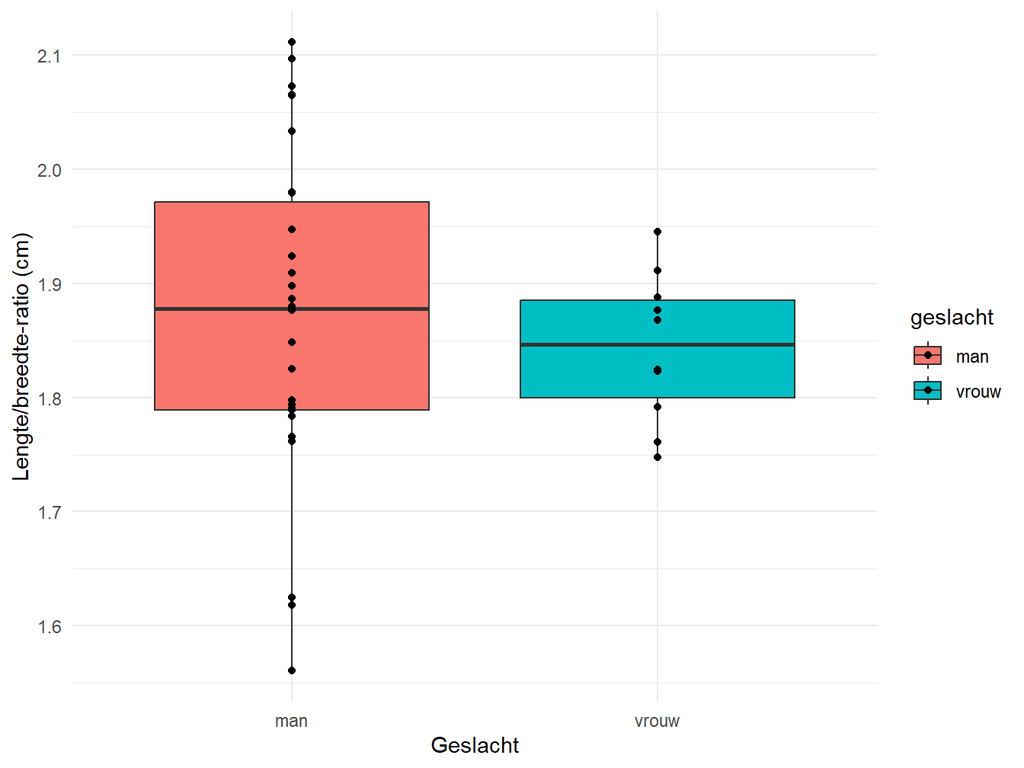

```r
ggplot(data = biometric_data,
       mapping = aes(x = geslacht, y = lengte_breedte_ratio, fill = geslacht)) +
    geom_boxplot() +
    geom_point() +
    labs(x = "Geslacht", y = "Lengte/breedte-ratio (cm)") +
    theme_minimal()
```

De boxen overlappen elkaar en beide medianen liggen binnen de box van de andere boxplot, dus is er een gering verschil in de handlengte/handbreedte-ratio tussen mannen en vrouwen.

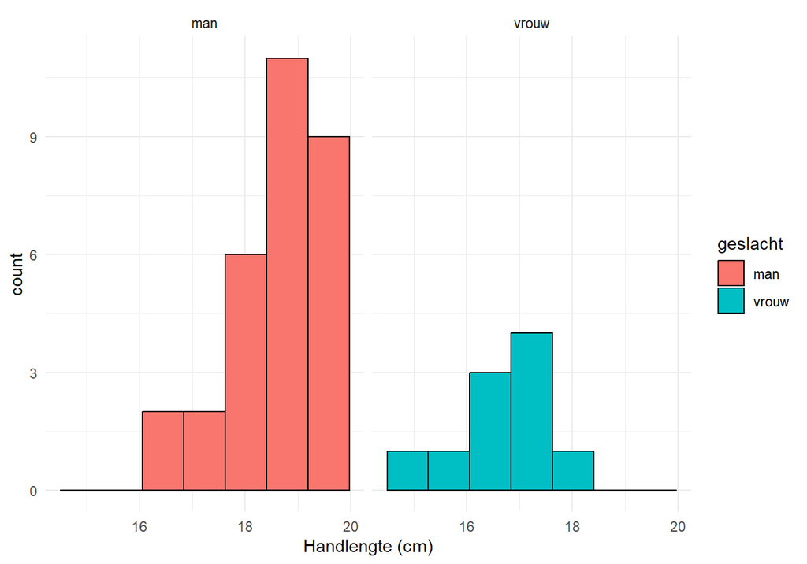

```r
ggplot(data = biometric_data,
       mapping = aes(x = handlengte, fill = geslacht)) +
    geom_histogram(bins = 1 + ceiling(log2(40)), colour = "black") + # histogram layer with using Sturge's rule to determine the number of bins. Source: https://medium.datadriveninvestor.com/how-to-decide-on-the-number-of-bins-of-a-histogram-3c36dc5b1cd8
    facet_wrap(. ~ geslacht) +                       # split plots over gender
    labs(x = "Handlengte (cm)") +
    theme_minimal()
```

De data in het histogram over de handlengte lijkt niet normaal verdeeld te zijn, maar verderop in dit bestand is een Shapiro-Wilk normality test gedaan en daaruit blijkt dat de data wel normaal verdeeld is. Dit komt denk ik doordat in het histogram de data over mannen en vrouwen apart weergegeven is, terwijl de Shapiro-Wilk normality test zonder onderscheid tussen mannen en vrouwen uitgevoerd is.

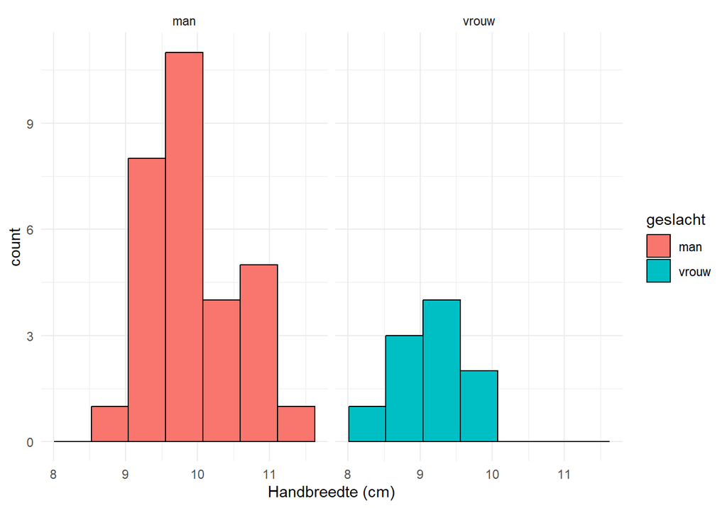

```r
ggplot(data = biometric_data,
       mapping = aes(x = handbreedte, fill = geslacht)) +
    geom_histogram(bins = 1 + ceiling(log2(40)), colour = "black") + # histogram layer with using Sturge's rule to determine the number of bins
    facet_wrap(. ~ geslacht) +                       # split plots over gender
    labs(x = "Handbreedte (cm)") +
    theme_minimal()
```

De data in het histogram over de handbreedte lijkt niet normaal verdeeld te zijn, maar verderop in dit bestand is een Shapiro-Wilk normality test gedaan en daaruit blijkt dat de data wel normaal verdeeld is. Dit komt denk ik doordat in het histogram de data over mannen en vrouwen apart weergegeven is, terwijl de Shapiro-Wilk normality test zonder onderscheid tussen mannen en vrouwen uitgevoerd is.

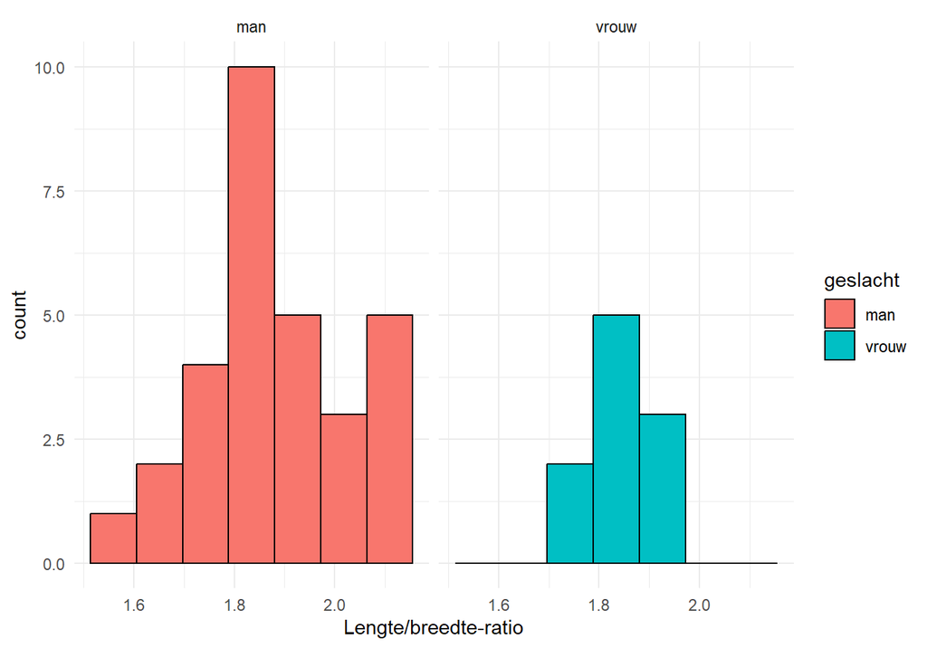

```r
ggplot(data = biometric_data,
       mapping = aes(x = lengte_breedte_ratio, fill = geslacht)) +
    geom_histogram(bins = 1 + ceiling(log2(40)), colour = "black") + # histogram layer with using Sturge's rule to determine the number of bins
    facet_wrap(. ~ geslacht) +                       # split plots over gender
    labs(x = "Lengte/breedte-ratio") +
    theme_minimal()
```

De data in het histogram over de handlengte lijkt niet normaal verdeeld te zijn, maar verderop in dit bestand is een Shapiro-Wilk normality test gedaan en daaruit blijkt dat de data wel normaal verdeeld is. Dit komt denk ik doordat in het histogram de data over mannen en vrouwen apart weergegeven is, terwijl de Shapiro-Wilk normality test zonder onderscheid tussen mannen en vrouwen uitgevoerd is. ### Welke verdeling?

```r
shapiro.test(biometric_data$handlengte)
```

```
##
##  Shapiro-Wilk normality test
##
## data:  biometric_data$handlengte
## W = 0.95494, p-value = 0.1122
```

```r
shapiro.test(biometric_data$handbreedte)
```

```
##
##  Shapiro-Wilk normality test
##
## data:  biometric_data$handbreedte
## W = 0.95872, p-value = 0.1514
```

```r
shapiro.test(biometric_data$lengte_breedte_ratio)
```

```
##
##  Shapiro-Wilk normality test
##
## data:  biometric_data$lengte_breedte_ratio
## W = 0.96462, p-value = 0.2402
```

Bij zowel de handlengte als handbreedte als lengte_breedte_ratio is de p-waarde (resp. 0.1122, 0.1514 en 0.2402) groter dan 0.05, dus is de verdeling van de steekproef niet significant verschillend van de normale verdeling. De t-test kan alleen bij een normaalverdeling gebruikt worden. Dus in dit geval kan de t-test gebruikt worden. Hieronder wordt de onafhankelijke t-test uitgevoerd.

```r
female_lengths <- subset(biometric_data,
                        subset = geslacht == "vrouw",
                        select = handlengte,
                        drop = T) # drop = T forces ro a vector
male_lengths <- subset(biometric_data,
                        subset = geslacht == "man",
                        select = handlengte,
                        drop = T)
t.test(female_lengths, male_lengths)
```

```
##
##  Welch Two Sample t-test
##
## data:  female_lengths and male_lengths
## t = -6.0986, df = 16.686, p-value = 1.282e-05
## alternative hypothesis: true difference in means is not equal to 0
## 95 percent confidence interval:
##  -2.490929 -1.209071
## sample estimates:
## mean of x mean of y
##     16.73     18.58
```

De p-waarde is 1.282e-05. Dit is kleiner dan 0.05, dus nulhypothese 1 wordt verworpen. Dit betekent dat er bewijs is gevonden voor een significant verschil bij de mens in handlengte tussen mannen en vrouwen.

```r
female_widths <- subset(biometric_data,
                        subset = geslacht == "vrouw",
                        select = handbreedte,
                        drop = T) # drop = T forces ro a vector
male_widths <- subset(biometric_data,
                        subset = geslacht == "man",
                        select = handbreedte,
                        drop = T)
t.test(female_widths, male_widths)
```

```
##
##  Welch Two Sample t-test
##
## data:  female_widths and male_widths
## t = -4.8427, df = 22.441, p-value = 7.335e-05
## alternative hypothesis: true difference in means is not equal to 0
## 95 percent confidence interval:
##  -1.2707022 -0.5092978
## sample estimates:
## mean of x mean of y
##      9.08      9.97
```

De p-waarde is 7.335e-05. Dit is kleiner dan 0.05, wat betekent dat nulhypothese 2 wordt verworpen. Dit betekent dat er bewijs is gevonden voor een significant verschil bij de mens in handbreedte tussen mannen en vrouwen.

```r
female_ratios <- subset(biometric_data,
                        subset = geslacht == "vrouw",
                        select = lengte_breedte_ratio,
                        drop = T) # drop = T forces ro a vector
male_ratios <- subset(biometric_data,
                        subset = geslacht == "man",
                        select = lengte_breedte_ratio,
                        drop = T)
t.test(female_ratios, male_ratios)
```

```
##
##  Welch Two Sample t-test
##
## data:  female_ratios and male_ratios
## t = -0.81325, df = 33.799, p-value = 0.4218
## alternative hypothesis: true difference in means is not equal to 0
## 95 percent confidence interval:
##  -0.09403992  0.04029477
## sample estimates:
## mean of x mean of y
##  1.843597  1.870470
```

De p-waarde = 0.4218. Dit is groter dan 0.05, dus nulhypothese 3 wordt niet verworpen. Dit betekent dat er geen bewijs is gevonden voor een significant verschil bij de mens in handlengte/handbreedte-ratio’s tussen mannen en vrouwen.

Hoe kleiner de steekproefgrootte (*sample size*) hoe lastiger het is de onderliggende verdeling vast te stellen. Speel maar eens met dit blokje code, en verander de steekproefgrootte (`n=`) in de `rnorm()` functie en de `breaks=` in de `hist()` functie. Neem voor *n* bijvoorbeeld achtereenvolgens 10, 100, 1000, 10000, 10000 en voor *breaks* 5, 10, 50. Wanneer zie je een echte normaalverdeling verschijnen?

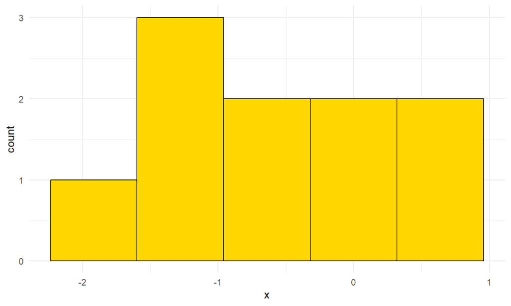

```r
hist_data <- data.frame(x = rnorm(n = 10))
ggplot(data = hist_data,
       mapping = aes(x = x)) +
    geom_histogram(bins = 5, fill = "gold", colour = "black") +
    theme_minimal()
```

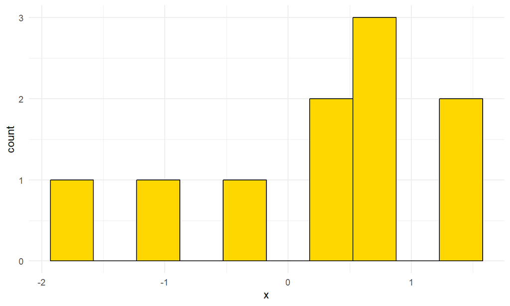

```r
hist_data <- data.frame(x = rnorm(n = 10))
ggplot(data = hist_data,
       mapping = aes(x = x)) +
    geom_histogram(bins = 10, fill = "gold", colour = "black") +
    theme_minimal()
```

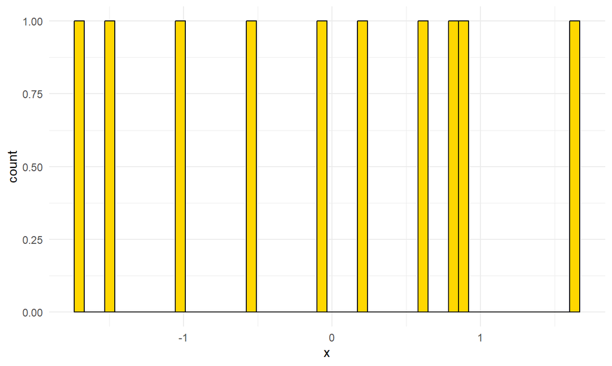

```r
hist_data <- data.frame(x = rnorm(n = 10))
ggplot(data = hist_data,
       mapping = aes(x = x)) +
    geom_histogram(bins = 50, fill = "gold", colour = "black") +
    theme_minimal()
```

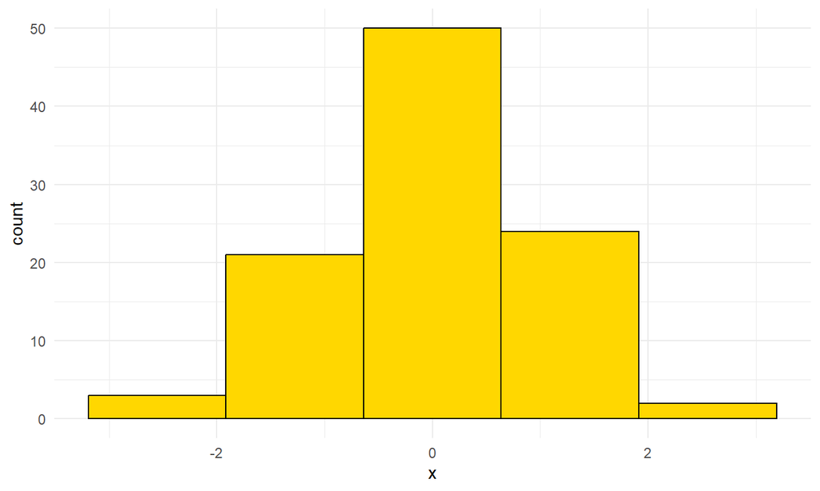

```r
hist_data <- data.frame(x = rnorm(n = 100))
ggplot(data = hist_data,
       mapping = aes(x = x)) +
    geom_histogram(bins = 5, fill = "gold", colour = "black") +
    theme_minimal()
```

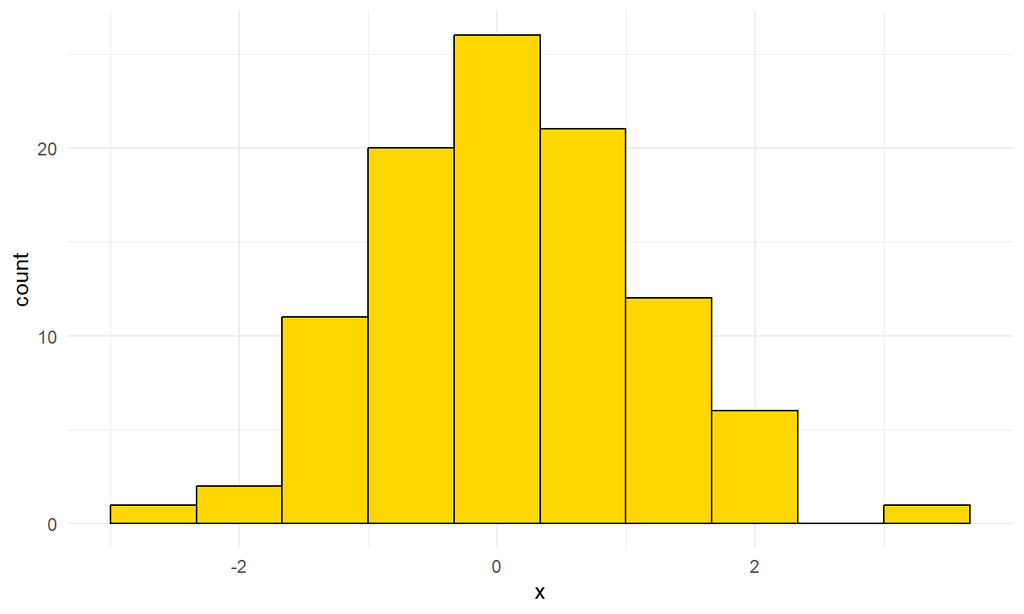

```r
hist_data <- data.frame(x = rnorm(n = 100))
ggplot(data = hist_data,
       mapping = aes(x = x)) +
    geom_histogram(bins = 10, fill = "gold", colour = "black") +
    theme_minimal()
```

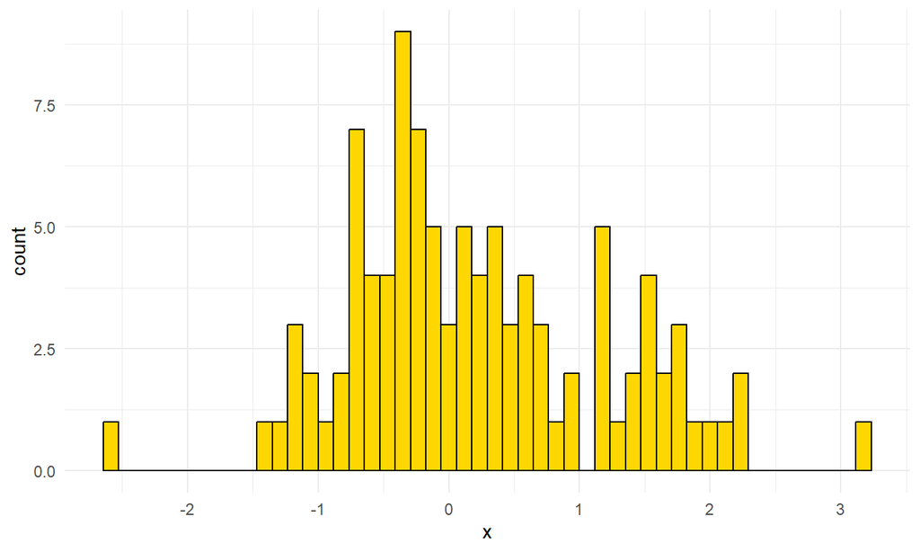

```r
hist_data <- data.frame(x = rnorm(n = 100))
ggplot(data = hist_data,
       mapping = aes(x = x)) +
    geom_histogram(bins = 50, fill = "gold", colour = "black") +
    theme_minimal()
```

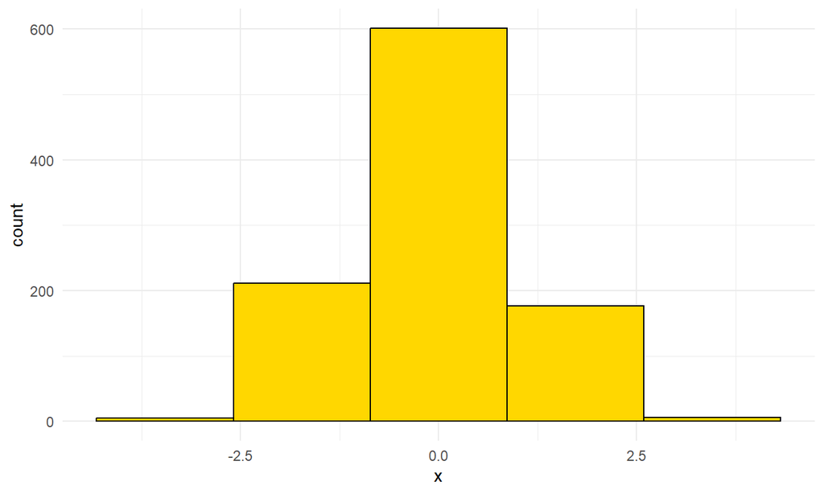

```r
hist_data <- data.frame(x = rnorm(n = 1000))
ggplot(data = hist_data,
       mapping = aes(x = x)) +
    geom_histogram(bins = 5, fill = "gold", colour = "black") +
    theme_minimal()
```

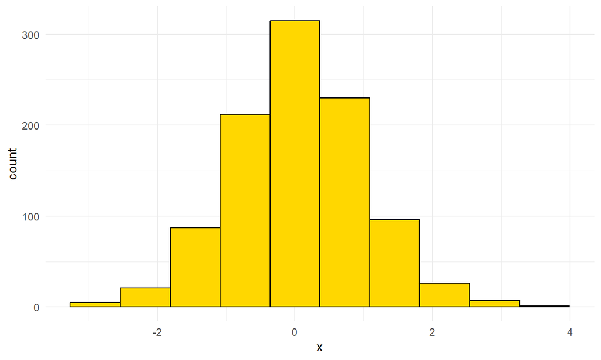

```r
hist_data <- data.frame(x = rnorm(n = 1000))
ggplot(data = hist_data,
       mapping = aes(x = x)) +
    geom_histogram(bins = 10, fill = "gold", colour = "black") +
    theme_minimal()
```

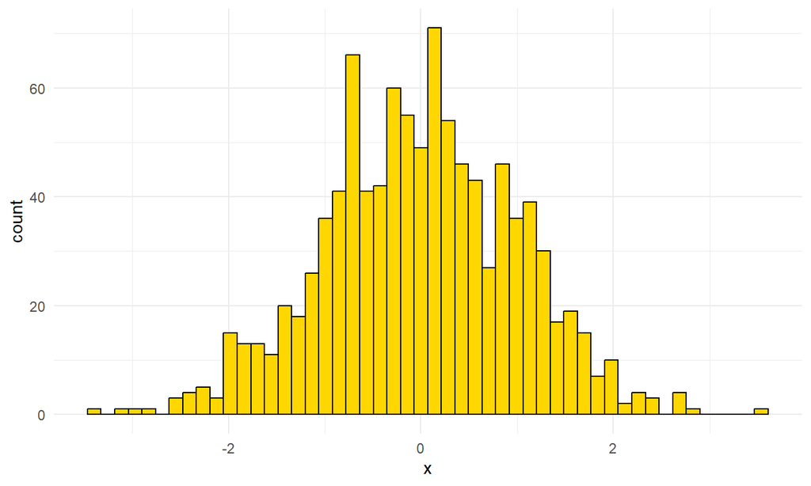

```r
hist_data <- data.frame(x = rnorm(n = 1000))
ggplot(data = hist_data,
       mapping = aes(x = x)) +
    geom_histogram(bins = 50, fill = "gold", colour = "black") +
    theme_minimal()
```

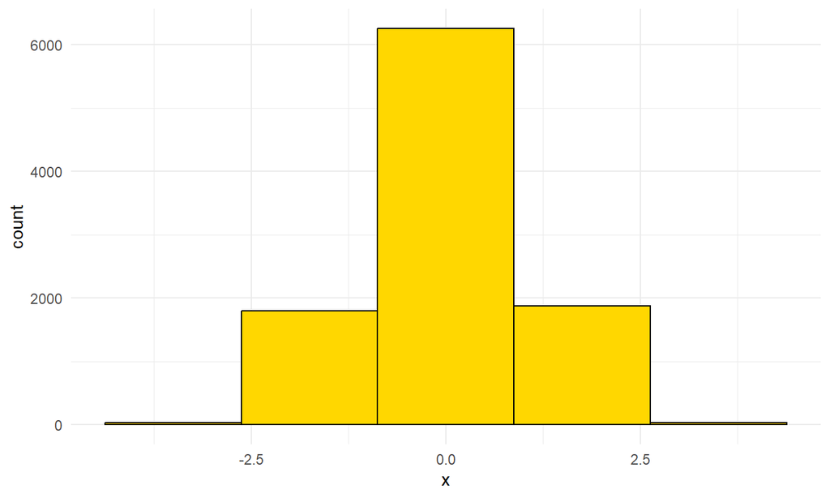

```r
hist_data <- data.frame(x = rnorm(n = 10000))
ggplot(data = hist_data,
       mapping = aes(x = x)) +
    geom_histogram(bins = 5, fill = "gold", colour = "black") +
    theme_minimal()
```

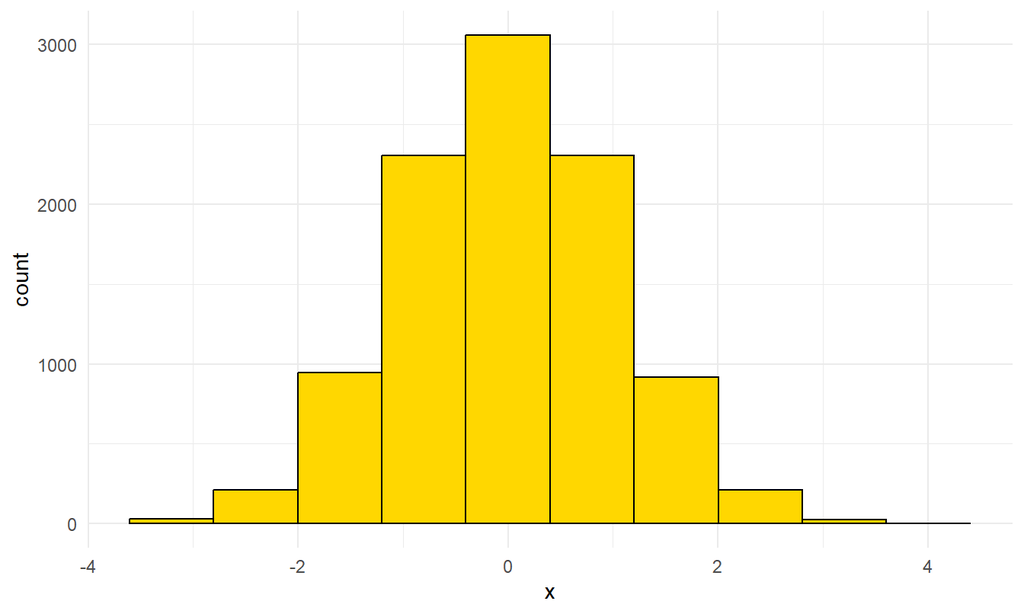

```r
hist_data <- data.frame(x = rnorm(n = 10000))
ggplot(data = hist_data,
       mapping = aes(x = x)) +
    geom_histogram(bins = 10, fill = "gold", colour = "black") +
    theme_minimal()
```

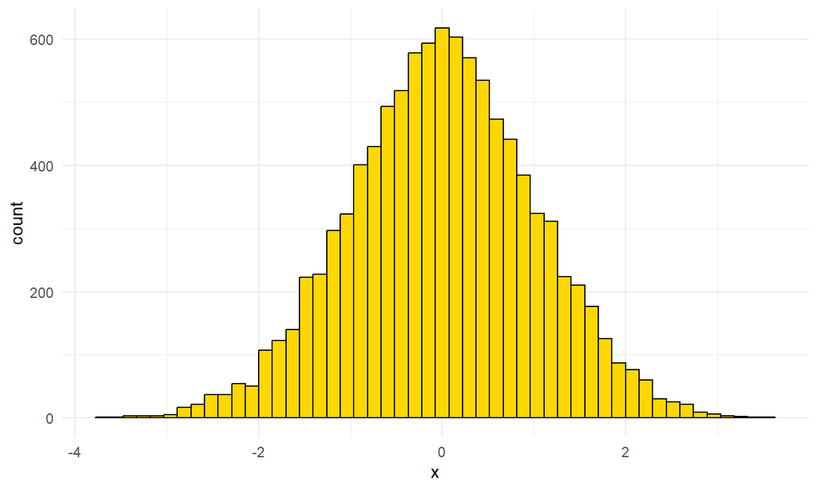

```r
hist_data <- data.frame(x = rnorm(n = 10000))
ggplot(data = hist_data,
       mapping = aes(x = x)) +
    geom_histogram(bins = 50, fill = "gold", colour = "black") +
    theme_minimal()
```

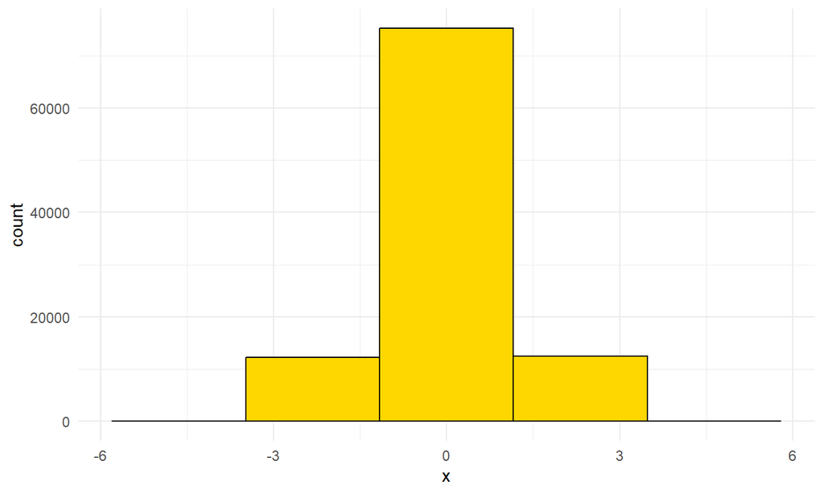

```r
hist_data <- data.frame(x = rnorm(n = 100000))
ggplot(data = hist_data,
       mapping = aes(x = x)) +
    geom_histogram(bins = 5, fill = "gold", colour = "black") +
    theme_minimal()
```

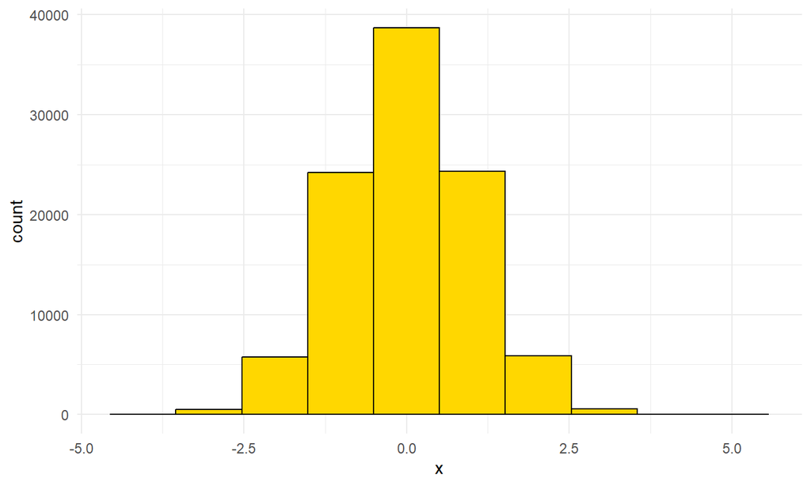

```r
hist_data <- data.frame(x = rnorm(n = 100000))
ggplot(data = hist_data,
       mapping = aes(x = x)) +
    geom_histogram(bins = 10, fill = "gold", colour = "black") +
    theme_minimal()
```

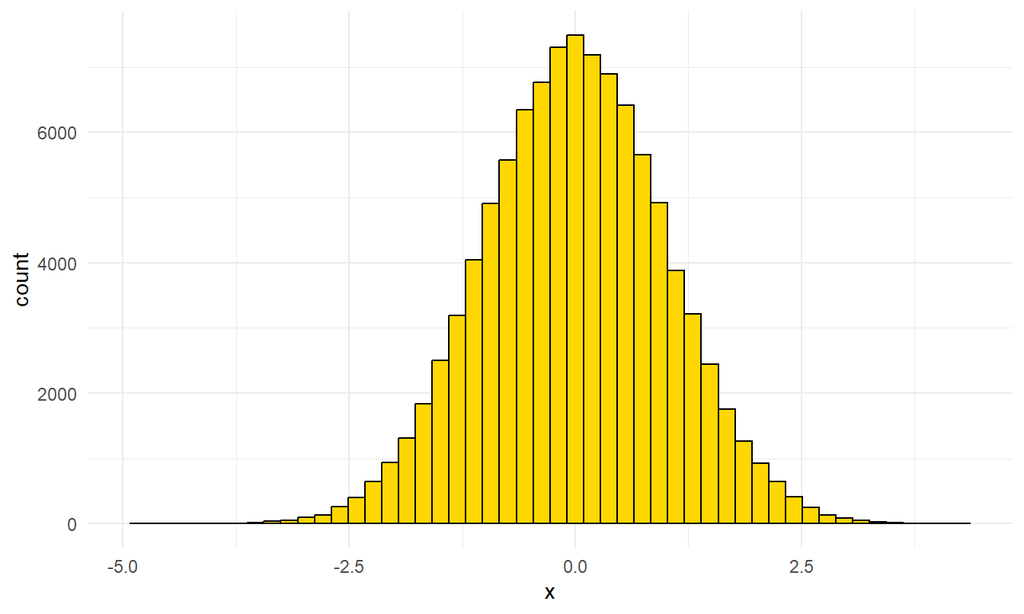

```r
hist_data <- data.frame(x = rnorm(n = 100000))
ggplot(data = hist_data,
       mapping = aes(x = x)) +
    geom_histogram(bins = 50, fill = "gold", colour = "black") +
    theme_minimal()
```

**Dit *experiment* met de argumenten van `rnorm()` en `hist()` moet je opnemen in je eigen RMarkdown.**  
Beantwoord deze vragen:

1. Wat gebeurt er met de vorm van de verdeling als `n` groter wordt?
2. Wat gebeurt er met de spreiding van de data (x-as) als `n` groter wordt, en kan je dat verklaren?
3. Waarom is bij zelfde instellingen voor `n` en `breaks` de uitkomst toch verschillend?
4. Welke minimale `n` geeft het meeste kans om een echte normaalverdeling te zien?
5. Wat voor bijzonders is er aan de hand met het `breaks` argument? Geeft de documentatie daar een verklaring voor?

https://r-charts.com/distribution/histogram-breaks/

https://www.scribbr.com/statistics/variability/#:~:text=Variability%20describes%20how%20far%20apart,as%20spread%2C%20scatter%20or%20dispersion.

### Bronnen van variatie

-Overerving: Ieder organisme erft een andere set allelen van de ouders (met uitzondering van eeneiigie meerlingen) ## Reflectie op het experiment

Bespreek in je groep de volgende vragen en voeg de antwoorden toe aan je uitgewerkte onderzoeksdocument.

1. Zijn de metingen tussen de verschillende meters ook (significant) verschillend? Zo ja, waardoor zou je de verschillen kunnen verklaren?

```r
data_file_ag <- "hand_metingen_ander_groepje.csv" # ag staat voor ander groepje.

#data format: laborant_ID,subject_ID,handlengte,handbreedte,sexe
biometric_data_ag <- read.table(file = data_file_ag,
                        header = TRUE,
                        sep = ",")

handlengte_ag <- biometric_data_ag[2]
handbreedte_ag <- biometric_data_ag[3]
lengte_breedte_ratio_ag <- handlengte_ag / handbreedte_ag
# Gebruikte bronnen voor onderstaande code in deze chunk:
# https://stackoverflow.com/questions/13079387/how-to-add-data-by-columns-in-csv-f# ile-using-r#:~:text=You%20can't%20append%20columns,file%20is%20stored%20on%2Ddis# k.
# https://how.dev/answers/what-are-the-rownames-and-colnames-functions-in-r
df_ratio_ag <- data.frame(lengte_breedte_ratio_ag)

tmp_ag <- read.csv("hand_metingen_ander_groepje.csv")
tmp_ag <- cbind(tmp_ag, df_ratio_ag)
colnames(tmp_ag) <- c("aantal_ag", "handlengte_ag", "handbreedte_ag", "geslacht_ag", "lengte_breedte_ratio_ag")
write.csv(tmp_ag, "hand_metingen_ander_groepje_v2.csv")
biometric_data_ag <- read.table(file = "hand_metingen_ander_groepje_v2.csv",
                        header = TRUE,
                        sep = ",")
```

```r
shapiro.test(biometric_data_ag$handlengte_ag)
```

```
##
##  Shapiro-Wilk normality test
##
## data:  biometric_data_ag$handlengte_ag
## W = 0.95282, p-value = 0.09485
```

Bij de handlengte van het andere groepje geeft de Shapiro-Wilk test een p-waarde van 0.09485. Dit is groter dan 0.05, dus is de verdeling van de steekproef niet significant verschillend van de normale verdeling. Dus de t-test kan in dit geval gebruikt worden.

```r
female_lengths_ag <- subset(biometric_data_ag,
                        subset = geslacht_ag == "V",
                        select = handlengte_ag,
                        drop = T) # drop = T forces ro a vector
male_lengths_ag <- subset(biometric_data_ag,
                        subset = geslacht_ag == "M",
                        select = handlengte_ag,
                        drop = T) # drop = T forces ro a vector
t.test(female_lengths_ag, male_lengths_ag)
```

```
##
##  Welch Two Sample t-test
##
## data:  female_lengths_ag and male_lengths_ag
## t = -5.9578, df = 18.964, p-value = 9.9e-06
## alternative hypothesis: true difference in means is not equal to 0
## 95 percent confidence interval:
##  -2.657662 -1.275672
## sample estimates:
## mean of x mean of y
##  17.00000  18.96667
```

Bij de handlengte van het andere groepje geeft de t-test een p-waarde van 9.9e-06. Dit is kleiner dan 0.05, dus bij het andere groepje wordt nulhypothese 1 verworpen. Dus er is bewijs gevonden voor een significant sekseverschil bij de mens bij de mens in de lengte van de hand.

```r
shapiro.test(biometric_data_ag$handbreedte_ag)
```

```
##
##  Shapiro-Wilk normality test
##
## data:  biometric_data_ag$handbreedte_ag
## W = 0.58769, p-value = 2.133e-09
```

```r
female_widths_ag <- subset(biometric_data_ag,
                        subset = geslacht_ag == "V",
                        select = handbreedte_ag,
                        drop = T) # drop = T forces ro a vector
male_widths_ag <- subset(biometric_data_ag,
                        subset = geslacht_ag == "M",
                        select = handbreedte_ag,
                        drop = T) # drop = T forces ro a vector
wilcox.test(female_widths_ag, male_widths_ag, exact = F)
```

```
##
##  Wilcoxon rank sum test with continuity correction
##
## data:  female_widths_ag and male_widths_ag
## W = 24, p-value = 6.341e-05
## alternative hypothesis: true location shift is not equal to 0
```

Bij de handbreedte van het andere groepje geeft de Mann-Whitney u test een p-waarde van 6.341e-05. Dit is kleiner dan 0.05, dus bij het andere groepje wordt nulhypothese 2 verworpen. Dus bij het andere groepje is er bewijs voor een significant sekseverschil bij de mens in de breedte van de hand.

Bij zowel mijn groepje als bij het andere groepje is er een significant verschil bij de mens gevonden in de handlengte tussen mannen en vrouwen. Hetzelfde geldt voor de handbreedte. Toch is uit de gemeten waarden van zowel de handlengte als -breedte gebleken dat mijn groepje iets andere waarden heeft gemeten dan het andere groepje.

2. Onderzoek de verschillen tussen mannen en vrouwen met betrekking tot hand lengte, handbreedte en de ratio. Er is een significant verschil bij de mens gevonden in de handlengte tussen mannen en vrouwen. Ditzelfde geldt ook voor de handbreedte, maar niet voor de handlengte/handbreedte-ratio.
3. Zou je het protocol aanpassen na deze ervaring, of was hij voldoende duidelijk en reproduceerbaar? Het protocol was niet voldoende duidelijk en ook niet reproduceerbaar, want mijn groepje heeft de metingen tot op 1 mm nauwkeurig in cm gedaan, maar het andere groepje heeft de metingen tot op 5 mm nauwkeurig in cm gedaan.

#### Wat je moet inleveren

Voor de verwerking en analyse van je eigen data maak je gebruik van het aangeleverde template RMarkdown document. Daarin doorloop je dezelfde onderzoek stappen als hieronder, maar dan met je eigen data. Aan het einde van de dag gaat dat document, in originele en “geknitte” vorm, samen met je databestand, in een git repo die is opgezet volgens voorschift in de cursushandleiding. De link hiernaar toe gaat in je portfolio op eJournal. Let op dat je *alle* stappen hebt doorlopen voordat je inlevert. Gebruik ook de RStudio spellingscontrole!  
Vergeet niet jullie namen en studentnummers bovenaan de markdown te zetten!